# Indel Signature InsDel1a

# InsDel1a

(corresponds to 83-type signature C_ID1 )

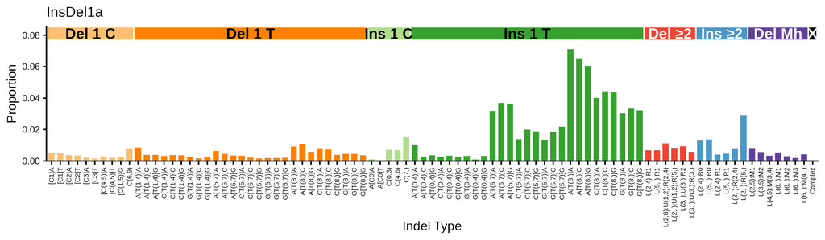

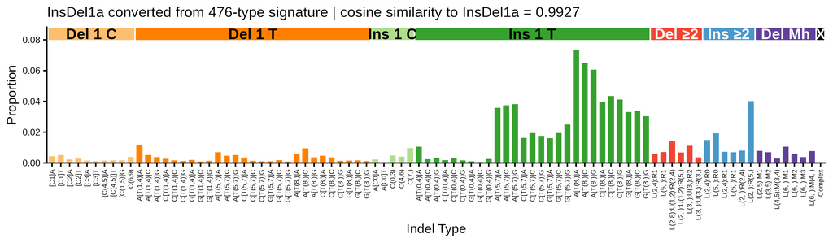

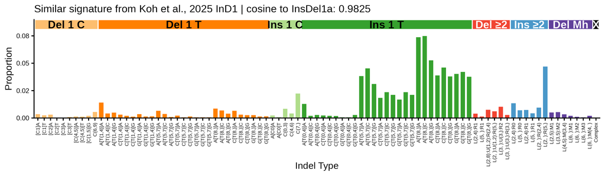

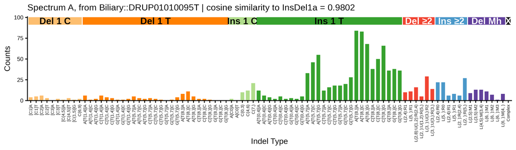

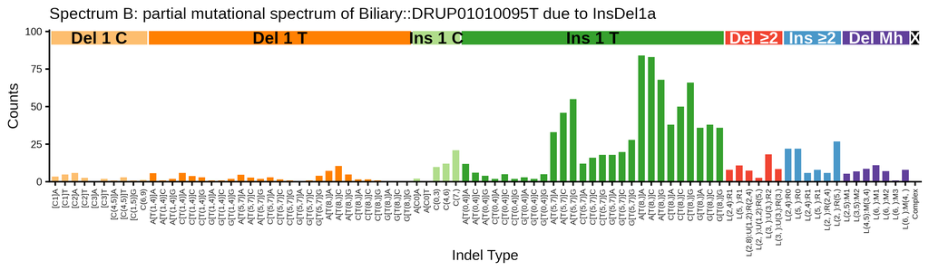

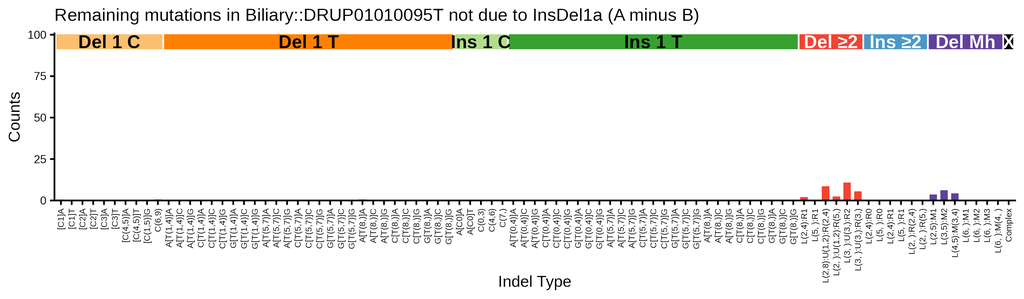

## 476-type representations corresponding to InsDel1a

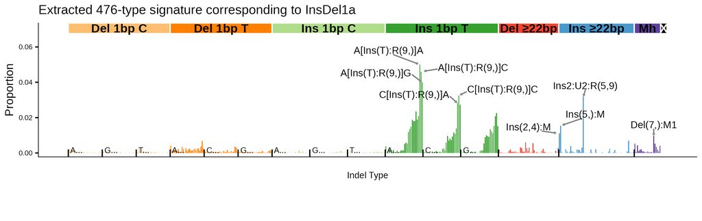

476-type spectrum of the supporting tumor Biliary::DRUP01010095T; cosine similarity to the extracted 476-type signature is 0.9597

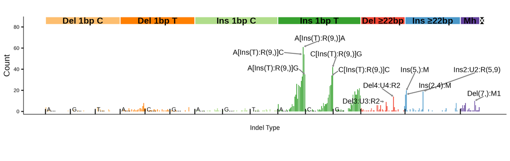

## 83-type signature corresponding to InsDel1a ( C_ID1 )

**Click here to show 83-type plots**

**Note**

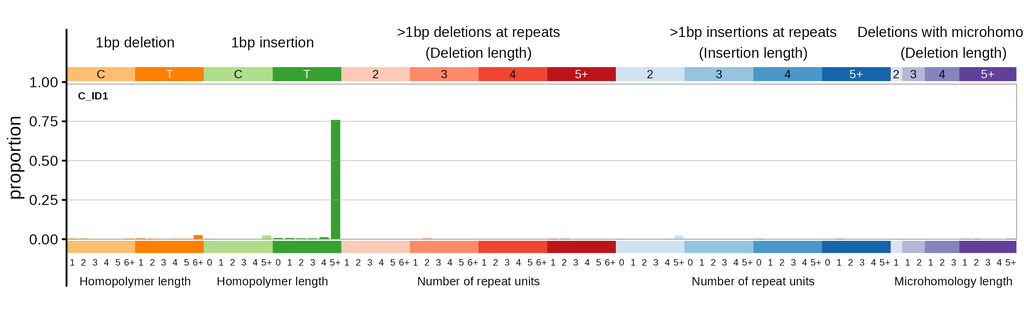

**Click here to see with insertions and deletions of T in long poly-T suppressed**

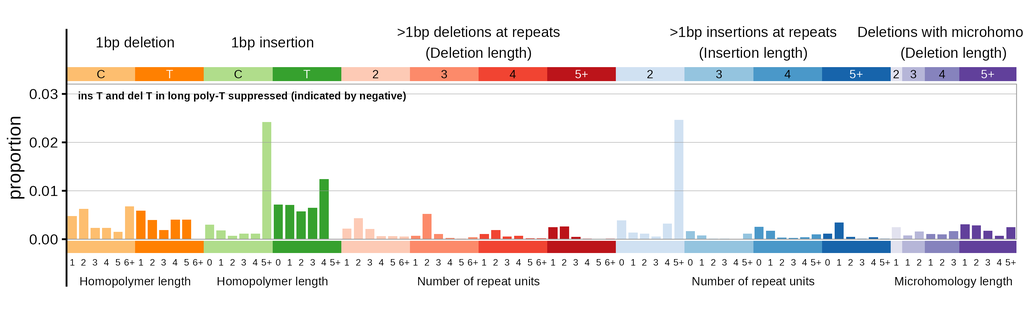

83-type signature converted from 476-type signature corresponding to InsDel1a | cosine similarity to C_ID1: 0.9977

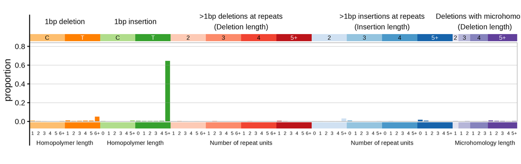

**Click here to see with insertions and deletions of T in long poly-T suppressed**

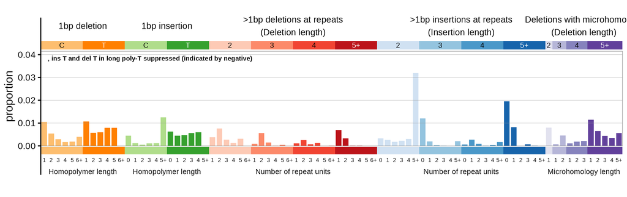

83-type spectrum of the supporting tumor Biliary::DRUP01010095T | cosine similarly to C_ID1: 0.9984

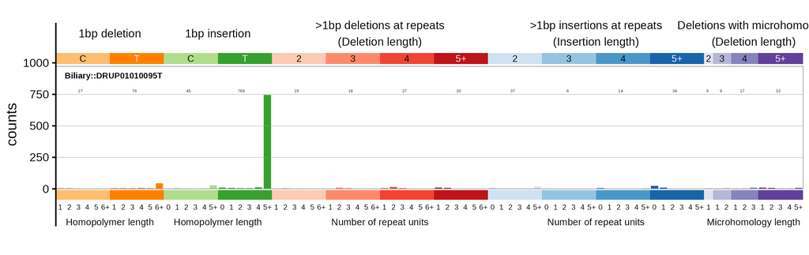

**Click here to see with insertions and deletions of T in long poly-T suppressed**

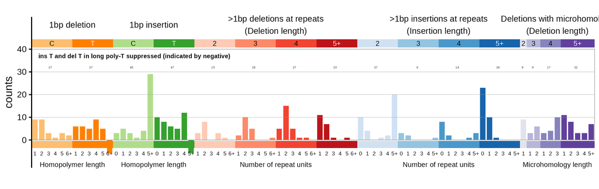

### Similar COSMIC signatures

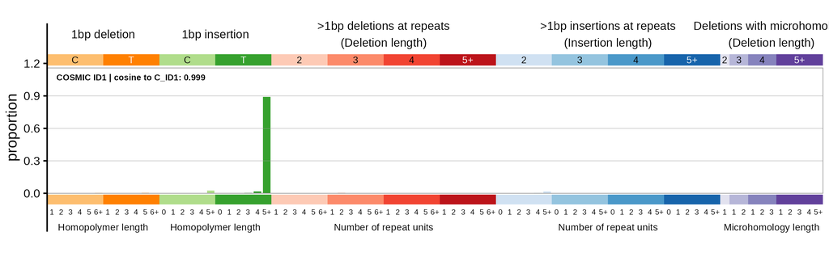

**Click here to see with insertions and deletions of T in long poly-T suppressed**

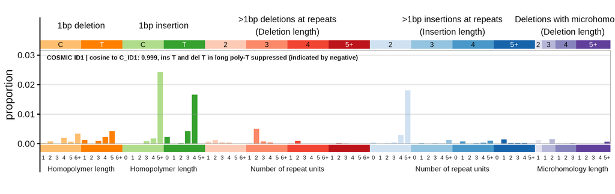

### Similar signatures from Jin et al. 2024

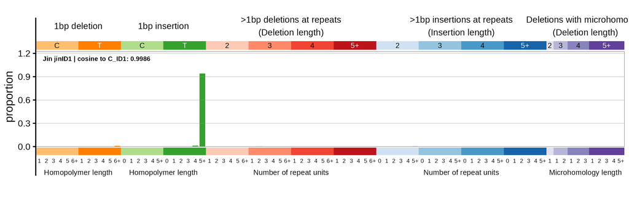

**Click here to see with insertions and deletions of T in long poly-T suppressed**

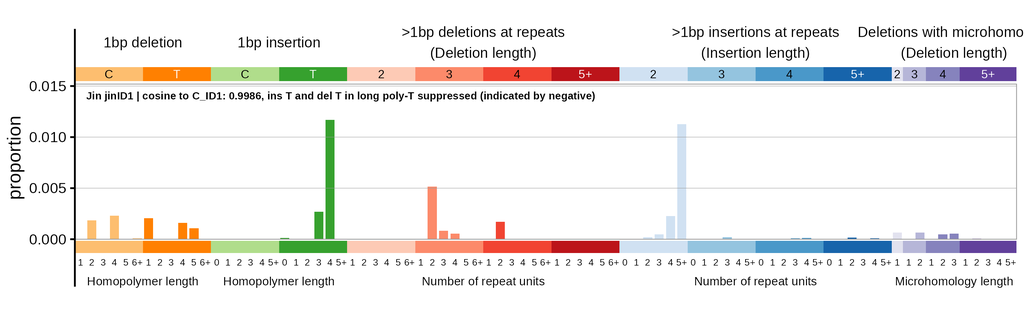